# T-Test Review

Adam Johnson

12/6/2021

## T-Test Review

This code will explore T-tests in R. T-Tests measure how significant the difference between two groups are, or in other words, if the means of two groups are different. T-Tests assume normal distributions and equal variances. The Null-Hypothesis of this test is that the means are the same. The Alternative is that the means are significantly different.

To begin, I will perform a T-test on the 5th and 6th Month of the Airquality Data set. I am going to be performing this test on the Temp variable, to see if there was any significant change in Temp between the two months.

First, since I want to focus on the Temp variable of Months 5 and 6, I have to filter this data out from the Airquality data set. I did this via the dplyr package and the filter function. This leaves me with two data frames, one that only contains data on Month 5, and one that contains data on Month 6.

```r
# Load the Dplyr Library for Data Manipulation
library(dplyr)

# Filters the data set into two separate data frames.  One for Month 5 and one for Month 6
Month5 <- airquality %>% filter(airquality$Month == "5")
Month6 <- airquality %>% filter(airquality$Month == "6")

# Combines both Month5 and Month6 into one single data frame
TempMonth <- rbind(Month5, Month6)
```

```r
# Code to get a glimpse of the Data
head(airquality)
```

```
##   Ozone Solar.R Wind Temp Month Day
## 1    41     190  7.4   67     5   1
## 2    36     118  8.0   72     5   2
## 3    12     149 12.6   74     5   3
## 4    18     313 11.5   62     5   4
## 5    NA      NA 14.3   56     5   5
## 6    28      NA 14.9   66     5   6
```

```r
# code to provide a summary of the Temp Variable
group_by(TempMonth, Month) %>%
  summarise(
    count = n(),
    mean = mean(Temp, na.rm = TRUE),
    sd = sd(Temp, na.rm = TRUE)
  )
```

```
## # A tibble: 2 x 4
##   Month count  mean    sd
##   <int> <int> <dbl> <dbl>
## 1     5    31  65.5  6.85
## 2     6    30  79.1  6.60
```

## Check for Normallcy

One of the assumptions of a T-test is that the data is normally distributed. To quickly check wether the Temp variable is normal, I performed a Shapiro-Wilk test. If this test provides a significant p-value, we can reject the null hypothesis and say that the the distribution is significantly different from normal.

```r
# Shapiro Test on Month5 Data Frame for Temp
shapiro.test(Month5$Temp)
```

```
##
##  Shapiro-Wilk normality test
##
## data:  Month5$Temp
## W = 0.94771, p-value = 0.1349
```

```r
# Shapiro Test on Month6 Data Frame for Temp
shapiro.test(Month6$Temp)
```

```
##
##  Shapiro-Wilk normality test
##
## data:  Month6$Temp
## W = 0.97158, p-value = 0.5832
```

Both of the outputs resulted in non-signicant p-values, which allows us to assume that both of the variables are normally distributed.

## Visual Check For Normallcy

As further confirmation of the data being normally distributed, I have created some density plots. These plots have a normal distribtion overlayed ontop of the actual data.

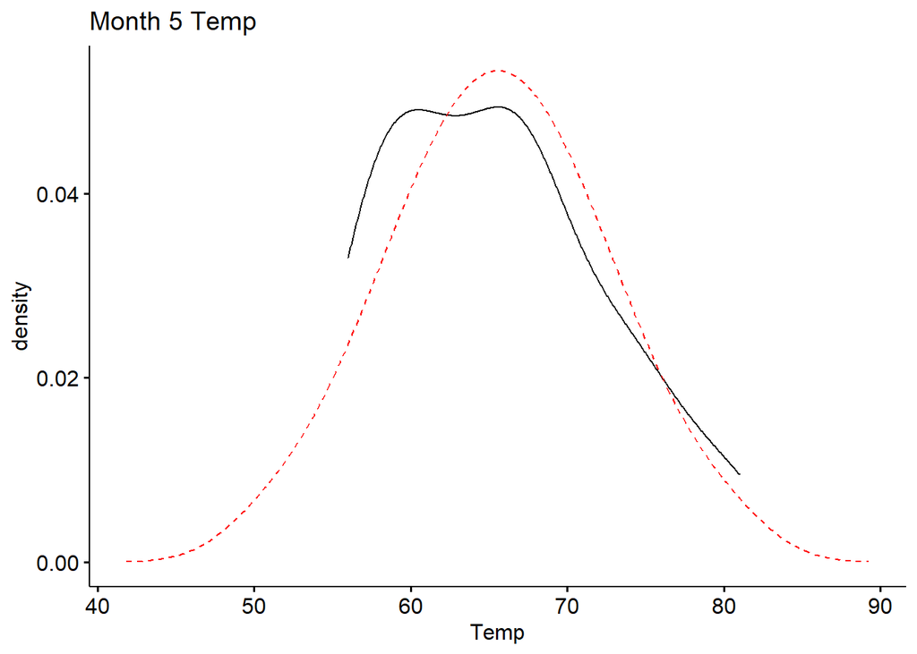

```r
# Load ggpubr package
library(ggpubr)

# Creates two Density plots.  One for Month 5 Temp, and one for Month 6 Temp
par(mfrow = c(1,2))
ggdensity(Month5$Temp, title = "Month 5 Temp", xlab = "Temp") +
  stat_overlay_normal_density(color = "red", linetype = "dashed")
```

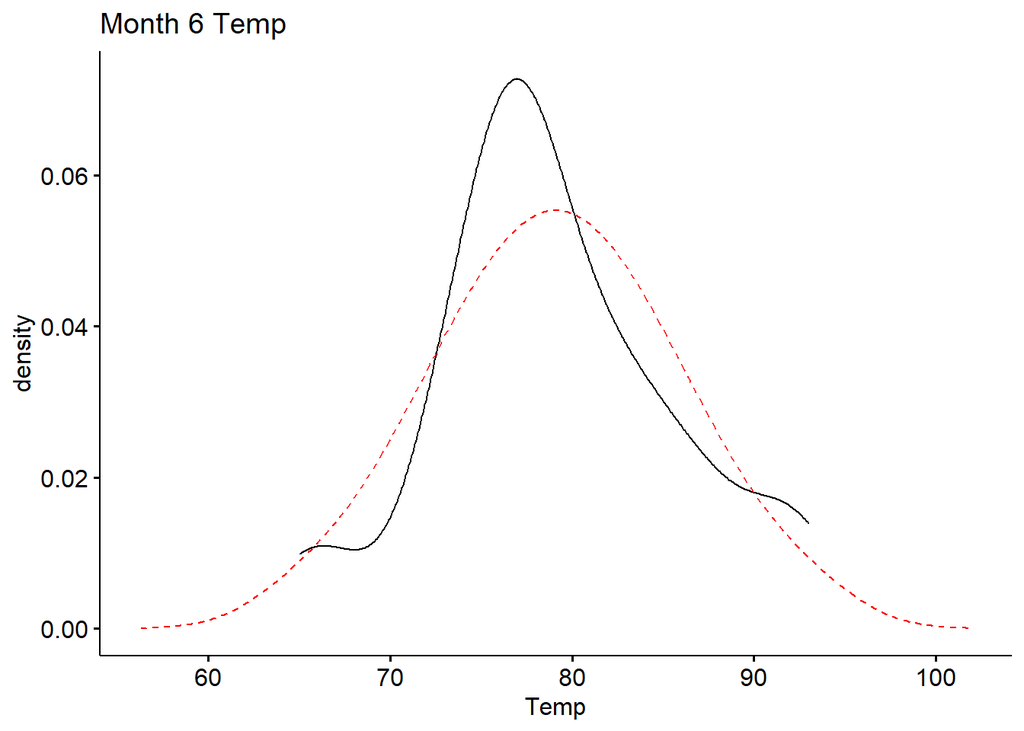

```r
ggdensity(Month6$Temp, title = "Month 6 Temp", xlab = "Temp") +
  stat_overlay_normal_density(color = "red", linetype = "dashed")
```

From the two density plots, we can see that both the Month 5 and the Month 6 Temp are appearing to follow a normal distribution.

## Equal Variance of the Data

Another assumption of the t-test is that the variance of the data is equal. One way to check if this is the case is through the var.test() function.

```r
# Performs Var.Test to check for equal variances
ftest <- var.test(Temp ~ Month, data = TempMonth)
ftest
```

```
##
##  F test to compare two variances
##
## data:  Temp by Month
## F = 1.0792, num df = 30, denom df = 29, p-value = 0.8391
## alternative hypothesis: true ratio of variances is not equal to 1
## 95 percent confidence interval:
##  0.5157852 2.2475782
## sample estimates:
## ratio of variances
##           1.079186
```

The F-Test gives a p-value of 0.8391, which is not significant. This means that we cannot reject the Null Hypothesis, therefore allowing us to assume that the variances between the groups are equal.

## T-Test

Now that Normality and equal variance of the data has been confirmed, we can conduct the t-test.

```r
# Performs T-Test
TestResult <- t.test(Temp ~ Month, data = TempMonth, var.equal = TRUE)
TestResult
```

```
##
##  Two Sample t-test
##
## data:  Temp by Month
## t = -7.8622, df = 59, p-value = 9.36e-11
## alternative hypothesis: true difference in means is not equal to 0
## 95 percent confidence interval:
##  -17.00061 -10.10262
## sample estimates:
## mean in group 5 mean in group 6
##        65.54839        79.10000
```

The output of the T-test gives a highly significant p-value. The means that we can reject the null hypothesis and accept the alternative. The Alternative Hypothesis says that there is a significant differences between the means of Temp in Months 5 and 6.

## Mean Plot Visualization

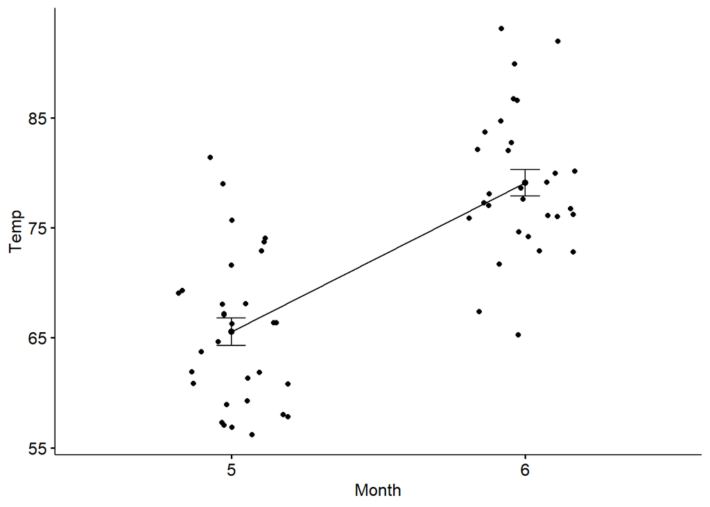

```r
# Plots Mean plot of Temp by Month
library("ggpubr")

ggline(TempMonth, x = "Month", y = "Temp",
       add = c("mean_se", "jitter"),
       order = c("Month", "5", "6"),
       ylab = "Temp", xlab = "Month")
```

The Mean plot further confirms the results of the t-test as it is very clear that the two groups have different means.